# A minimal example with `WeightIt` package

Author

Maciej Beręsewicz

# 1 Introduction

Here is a minimal example of how to use the [`WeightIt`](https://cran.r-project.org/package=WeightIt) package with the proposed approach.

# 2 Installation

Load packages

```r
library(WeightIt)
library(cobalt)
library(marginaleffects)
library(laeken) ## for weighted quantiles
library(CBPS) ## for LaLonde data
```

# 3 Data

Load data (3212 rows)

```r
data("LaLonde", package = "CBPS")
head(LaLonde)
```

|  | exper | treat | age | educ | black | hisp | married | nodegr | re74 | re75 | re78 | re74.miss |
| --- | --- | --- | --- | --- | --- | --- | --- | --- | --- | --- | --- | --- |
| 298 | 0 | 0 | 47 | 12 | 0 | 0 | 0 | 0 | 0 | 0 | 0 | 0 |
| 299 | 0 | 0 | 50 | 12 | 1 | 0 | 1 | 0 | 0 | 0 | 0 | 1 |
| 300 | 0 | 0 | 44 | 12 | 0 | 0 | 0 | 0 | 0 | 0 | 0 | 0 |
| 301 | 0 | 0 | 28 | 12 | 1 | 0 | 1 | 0 | 0 | 0 | 0 | 1 |
| 302 | 0 | 0 | 54 | 12 | 0 | 0 | 1 | 0 | 0 | 0 | 0 | 1 |
| 303 | 0 | 0 | 55 | 12 | 0 | 1 | 1 | 0 | 0 | 0 | 0 | 1 |

Compare means with `cobalt::bal.tab`.

```r
bal.tab(treat ~ age + educ + black + hisp + married + nodegr + re74 + re75,
        data = LaLonde, estimand = "ATT", thresholds = c(m = .05))
```

```
Balance Measures
           Type Diff.Un      M.Threshold.Un
age     Contin. -1.3023 Not Balanced, >0.05
educ    Contin. -0.8006 Not Balanced, >0.05
black    Binary  0.4706 Not Balanced, >0.05
hisp     Binary  0.0500 Not Balanced, >0.05
married  Binary -0.5946 Not Balanced, >0.05
nodegr   Binary  0.3512 Not Balanced, >0.05
re74    Contin. -2.3492 Not Balanced, >0.05
re75    Contin. -2.8019 Not Balanced, >0.05

Balance tally for mean differences
                    count
Balanced, <0.05         0
Not Balanced, >0.05     8

Variable with the greatest mean difference
 Variable Diff.Un      M.Threshold.Un
     re75 -2.8019 Not Balanced, >0.05

Sample sizes
    Control Treated
All    2915     297
```

# 4 Entropy balancing

## 4.1 Standard entropy balancing

Initial weighting with entropy balancing.

```r
ebal_result1 <- weightit(treat ~ age + educ + black + hisp + married + nodegr + re74 + re75,
                         data = LaLonde, estimand = "ATT", method = "ebal")
summary(ebal_result1)
```

```
                 Summary of weights

- Weight ranges:

        Min                                 Max
treated   1    ||                         1.000
control   0 |---------------------------| 8.949

- Units with the 5 most extreme weights by group:

           2507   2499   2494   2492  2491
 treated      1      1      1      1     1
           3047   3045   2704   3020  2886
 control 8.8397 8.8397 8.8397 8.8526 8.949

- Weight statistics:

        Coef of Var   MAD Entropy # Zeros
treated       0.000 0.000   0.000       0
control       2.005 1.311   1.246       0

- Effective Sample Sizes:

           Control Treated
Unweighted 2915.       297
Weighted    580.61     297
```

Balance statistics after entropy balancing.

```r
bal.tab(ebal_result1, stats = c("m", "v", "ks"), thresholds = c(m = .05))
```

```
Balance Measures
           Type Diff.Adj     M.Threshold V.Ratio.Adj KS.Adj
age     Contin.  -0.0002 Balanced, <0.05      0.7430 0.0617
educ    Contin.  -0.0000 Balanced, <0.05      0.7684 0.0364
black    Binary  -0.0000 Balanced, <0.05           . 0.0000
hisp     Binary   0.0000 Balanced, <0.05           . 0.0000
married  Binary  -0.0001 Balanced, <0.05           . 0.0001
nodegr   Binary  -0.0001 Balanced, <0.05           . 0.0001
re74    Contin.  -0.0000 Balanced, <0.05      0.9936 0.0295
re75    Contin.   0.0003 Balanced, <0.05      0.9042 0.0695

Balance tally for mean differences
                    count
Balanced, <0.05         8
Not Balanced, >0.05     0

Variable with the greatest mean difference
 Variable Diff.Adj     M.Threshold
     re75   0.0003 Balanced, <0.05

Effective sample sizes
           Control Treated
Unadjusted 2915.       297
Adjusted    580.61     297
```

## 4.2 Entropy balancing with proposed approach – step-by-step

Now calculate quantiles for continuous variables for the treatment group.

```r
age_tq <- with( subset(LaLonde, treat == 1), quantile(age))
educ_tq <- with( subset(LaLonde, treat == 1), quantile(educ))
re74_tq <- with( subset(LaLonde, treat == 1), quantile(re74))
re75_tq <- with( subset(LaLonde, treat == 1), quantile(re75))

n_t <- sum(LaLonde$treat) ## number of rows
```

Add new variables using the Heavyside function approximation using the logistic function. Here we only give an example for the median and Q3.

```r
LaLonde$age_50 <- with(LaLonde, plogis(-2000*(age-age_tq[3]))/n_t)
LaLonde$educ_50 <- with(LaLonde, plogis(-2000*(educ-educ_tq[3]))/n_t)
LaLonde$re74_50 <- with(LaLonde, plogis(-2000*(re74-re74_tq[3]))/n_t)
LaLonde$re75_50 <- with(LaLonde, plogis(-2000*(re75-re75_tq[3]))/n_t)

LaLonde$age_75 <- with(LaLonde, plogis(-2000*(age-age_tq[4]))/n_t)
LaLonde$educ_75 <- with(LaLonde, plogis(-2000*(educ-educ_tq[4]))/n_t)
LaLonde$re74_75 <- with(LaLonde, plogis(-2000*(re74-re74_tq[4]))/n_t)
LaLonde$re75_75 <- with(LaLonde, plogis(-2000*(re75-re75_tq[4]))/n_t)
```

Check that the variables sum to 0.5, as the treatment sample is small they may not sum to 0.5 (as in the `educ` variable).

```r
aggregate(age_50 ~ treat, LaLonde, sum)
```

| treat | age_50 |
| --- | --- |
| 0 | 1.7659933 |
| 1 | 0.4814815 |

```r
aggregate(educ_50 ~ treat, LaLonde, sum)
```

| treat | educ_50 |
| --- | --- |
| 0 | 3.2525253 |
| 1 | 0.6010101 |

```r
aggregate(re74_50 ~ treat, LaLonde, sum)
```

| treat | re74_50 |
| --- | --- |
| 0 | 1.484849 |
| 1 | 0.500000 |

```r
aggregate(re75_50 ~ treat, LaLonde, sum)
```

| treat | re75_50 |
| --- | --- |
| 0 | 1.646465 |
| 1 | 0.500000 |

Now add the newly handled variables to the `weightit` function.

```r
ebal_result2 <- weightit(treat ~ age + educ + black + hisp + married + nodegr + re74 + re75 +
                            age_50 + educ_50 + re74_50 + re75_50 +
                            age_75 + educ_75 + re74_75 + re75_75,
                          data = LaLonde, estimand = "ATT", method = "ebal")
summary(ebal_result2)
```

```
                 Summary of weights

- Weight ranges:

        Min                                   Max
treated   1   ||                           1.0000
control   0 |---------------------------| 13.0313

- Units with the 5 most extreme weights by group:

            2507   2499    2494    2492    2491
 treated       1      1       1       1       1
            3029   2702    2578    2869    2691
 control 10.2286 10.562 10.6094 11.1909 13.0313

- Weight statistics:

        Coef of Var   MAD Entropy # Zeros
treated       0.000 0.000    0.00       0
control       2.019 1.332    1.28       1

- Effective Sample Sizes:

           Control Treated
Unweighted 2915.       297
Weighted    574.36     297
```

Check that newly created variables are balanced.

```r
bal.tab(ebal_result2, stats = c("m", "v", "ks"), thresholds = c(m = .05))
```

```
Balance Measures
           Type Diff.Adj     M.Threshold V.Ratio.Adj KS.Adj
age     Contin.   0.0001 Balanced, <0.05      0.9023 0.0292
educ    Contin.  -0.0001 Balanced, <0.05      0.8396 0.0219
black    Binary  -0.0000 Balanced, <0.05           . 0.0000
hisp     Binary  -0.0001 Balanced, <0.05           . 0.0001
married  Binary   0.0000 Balanced, <0.05           . 0.0000
nodegr   Binary   0.0000 Balanced, <0.05           . 0.0000
re74    Contin.  -0.0001 Balanced, <0.05      1.0915 0.0193
re75    Contin.  -0.0002 Balanced, <0.05      1.0715 0.0484
age_50  Contin.  -0.0000 Balanced, <0.05      0.9942 0.0035
educ_50 Contin.  -0.0000 Balanced, <0.05      1.0015 0.0001
re74_50 Contin.  -0.0000 Balanced, <0.05      0.9983 0.0017
re75_50 Contin.   0.0001 Balanced, <0.05      0.9983 0.0017
age_75  Contin.   0.0000 Balanced, <0.05      0.9510 0.0185
educ_75 Contin.   0.0001 Balanced, <0.05      1.0014 0.0000
re74_75 Contin.   0.0000 Balanced, <0.05      0.9971 0.0017
re75_75 Contin.  -0.0000 Balanced, <0.05      0.9972 0.0017

Balance tally for mean differences
                    count
Balanced, <0.05        16
Not Balanced, >0.05     0

Variable with the greatest mean difference
 Variable Diff.Adj     M.Threshold
     re75  -0.0002 Balanced, <0.05

Effective sample sizes
           Control Treated
Unadjusted 2915.       297
Adjusted    574.36     297
```

Compare distribution of weights.

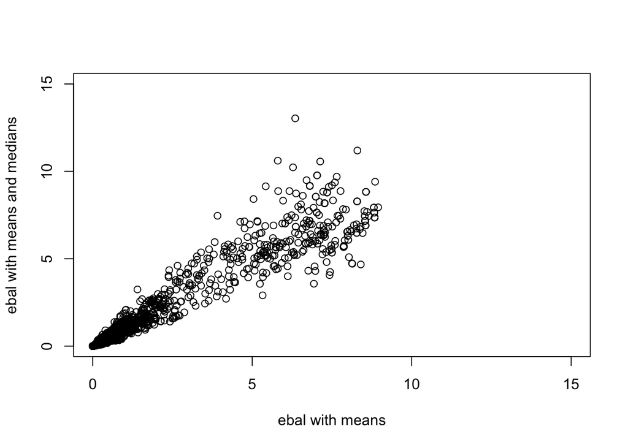

```r
plot(x=ebal_result1$weights, y=ebal_result2$weights,
     xlim = c(0, 15), ylim = c(0, 15),
     xlab = "ebal with means",
     ylab = "ebal with means and medians")
```

## 4.3 Entropy balancing with proposed approach – new implementation

Now, we will use the approach implemented in the new version of `WeightIt`. Note that

- `weightit()` uses `plogis` as in the example above,
- `weightit()` does not allow to balance on quantiles only.

```r
ebal_result3 <- weightit(formula = treat ~ age + educ + black + hisp + married + nodegr + re74 + re75,
                         data = LaLonde, estimand = "ATT", method = "ebal",
                         quantile = list(age = c(0.50, 0.75),
                                         educ = c(0.50, 0.75),
                                         re74 = c(0.50, 0.75),
                                         re75 = c(0.50, 0.75)))
# alternatively
ebal_result3 <- weightit(formula = treat ~ age + educ + black + hisp + married + nodegr + re74 + re75,
                         data = LaLonde, estimand = "ATT", method = "ebal",
                         quantile = list(c(0.50, 0.75)))

summary(ebal_result3)
```

```
                 Summary of weights

- Weight ranges:

        Min                                   Max
treated   1   ||                           1.0000
control   0 |---------------------------| 13.0313

- Units with the 5 most extreme weights by group:

            2507   2499    2494    2492    2491
 treated       1      1       1       1       1
            3029   2702    2578    2869    2691
 control 10.2286 10.562 10.6094 11.1909 13.0313

- Weight statistics:

        Coef of Var   MAD Entropy # Zeros
treated       0.000 0.000    0.00       0
control       2.019 1.332    1.28       1

- Effective Sample Sizes:

           Control Treated
Unweighted 2915.       297
Weighted    574.36     297
```

Check balance but note that variables listed in `quantile` are not reported. They are treated in a similar way as matching 2nd etc moments.

```r
bal.tab(ebal_result3, stats = c("m", "v", "ks"), thresholds = c(m = .05))
```

```
Balance Measures
           Type Diff.Adj     M.Threshold V.Ratio.Adj KS.Adj
age     Contin.   0.0001 Balanced, <0.05      0.9023 0.0292
educ    Contin.  -0.0001 Balanced, <0.05      0.8396 0.0219
black    Binary  -0.0000 Balanced, <0.05           . 0.0000
hisp     Binary  -0.0001 Balanced, <0.05           . 0.0001
married  Binary   0.0000 Balanced, <0.05           . 0.0000
nodegr   Binary   0.0000 Balanced, <0.05           . 0.0000
re74    Contin.  -0.0001 Balanced, <0.05      1.0915 0.0193
re75    Contin.  -0.0002 Balanced, <0.05      1.0715 0.0484

Balance tally for mean differences
                    count
Balanced, <0.05         8
Not Balanced, >0.05     0

Variable with the greatest mean difference
 Variable Diff.Adj     M.Threshold
     re75  -0.0002 Balanced, <0.05

Effective sample sizes
           Control Treated
Unadjusted 2915.       297
Adjusted    574.36     297
```

Compare distribution of weights.

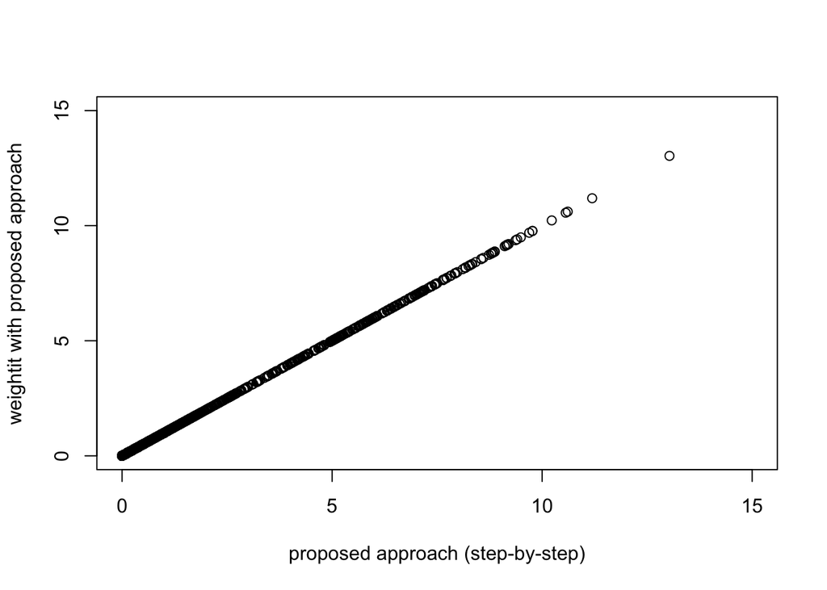

```r
plot(x=ebal_result2$weights, y=ebal_result3$weights,
     xlim = c(0, 15), ylim = c(0, 15),
     xlab = "proposed approach (step-by-step)",
     ylab = "weightit with proposed approach")
```

## 4.4 Results

Add both weights to the `LaLonde` data.frame.

```r
LaLonde$weights1 <- ebal_result1$weights
LaLonde$weights2 <- ebal_result2$weights
```

Compare weighted medians for selected variables.

```r
data.frame(
  age_treat = with(subset(LaLonde, treat == 1), median(age)),
  age_before_cont = with(subset(LaLonde, treat == 0), median(age)),
  age_after_ebal1 = with(subset(LaLonde, treat == 0), weightedMedian(age, weights1)),
  age_after_ebal2 = with(subset(LaLonde, treat == 0), weightedMedian(age, weights2))
)
```

| age_treat | age_before_cont | age_after_ebal1 | age_after_ebal2 |
| --- | --- | --- | --- |
| 23 | 31 | 22 | 23 |

```r
data.frame(
  educ_treat = with(subset(LaLonde, treat == 1), median(educ)),
  educ_before_cont = with(subset(LaLonde, treat == 0), median(educ)),
  educ_after_ebal1 = with(subset(LaLonde, treat == 0), weightedMedian(educ, weights1)),
  educ_after_ebal2 = with(subset(LaLonde, treat == 0), weightedMedian(educ, weights2))
)
```

| educ_treat | educ_before_cont | educ_after_ebal1 | educ_after_ebal2 |
| --- | --- | --- | --- |
| 11 | 12 | 10 | 11 |

```r
data.frame(
  re74_treat = with(subset(LaLonde, treat == 1), median(re74)),
  re74_before_cont = with(subset(LaLonde, treat == 0), median(re74)),
  re74_after_ebal1 = with(subset(LaLonde, treat == 0), weightedMedian(re74, weights1)),
  re74_after_ebal2 = with(subset(LaLonde, treat == 0), weightedMedian(re74, weights2))
)
```

| re74_treat | re74_before_cont | re74_after_ebal1 | re74_after_ebal2 |
| --- | --- | --- | --- |
| 858.2543 | 15700 | 827.9503 | 827.9503 |

```r
data.frame(
  re75_treat = with(subset(LaLonde, treat == 1), median(re75)),
  re75_before_cont = with(subset(LaLonde, treat == 0), median(re75)),
  re75_after_ebal1 = with(subset(LaLonde, treat == 0), weightedMedian(re75, weights1)),
  re75_after_ebal2 = with(subset(LaLonde, treat == 0), weightedMedian(re75, weights2))
)
```

| re75_treat | re75_before_cont | re75_after_ebal1 | re75_after_ebal2 |
| --- | --- | --- | --- |
| 1117.439 | 15900 | 664.569 | 1122.621 |

We can also see that KS statistic is lower (thus better) for entropy balancing of means and medians.

```r
tab1 <- bal.tab(ebal_result1, stats = "ks")
tab2 <- bal.tab(ebal_result2, stats = "ks")
data.frame(vars = rownames(tab1$Balance)[1:8],
           "EB"= tab1$Balance$KS.Adj[1:8]*100,
           "DEB" = tab2$Balance$KS.Adj[1:8]*100)
```

| vars | EB | DEB |
| --- | --- | --- |
| age | 6.1730827 | 2.9175983 |
| educ | 3.6374973 | 2.1880005 |
| black | 0.0035126 | 0.0015231 |
| hisp | 0.0046218 | 0.0072445 |
| married | 0.0052990 | 0.0007993 |
| nodegr | 0.0060626 | 0.0023945 |
| re74 | 2.9470993 | 1.9259753 |
| re75 | 6.9536964 | 4.8392098 |

Fit two models. We do not add `*_50` and `*_75` variables as they are only used to calibrate the weights.

```r
fit1 <- lm(re78 ~ treat * (age + educ + black + hisp + married + nodegr + re74 + re75),
           data = LaLonde, weights = weights1)
fit2 <- lm(re78 ~ treat * (age + educ + black + hisp + married + nodegr + re74 + re75),
           data = LaLonde, weights = weights2)
```

Estimate ATT using the first set of weights and the `marginaleffects::avg_comparisons` function.

```r
avg_comparisons(fit1, variables = "treat",
                vcov = "HC3",
                newdata = subset(LaLonde, treat == 1),
                wts = "weights1")
```

| term | contrast | estimate | std.error | statistic | p.value | s.value | conf.low | conf.high |
| --- | --- | --- | --- | --- | --- | --- | --- | --- |
| treat | 1 - 0 | -378.4214 | 468.6016 | -0.8075547 | 0.4193469 | 1.253784 | -1296.864 | 540.0208 |

Estimate ATT using the second set of weights and the `marginaleffects::avg_comparisons` function.

```r
avg_comparisons(fit2,
                variables = "treat",
                vcov = "HC3",
                newdata = subset(LaLonde, treat == 1),
                wts = "weights2")
```

| term | contrast | estimate | std.error | statistic | p.value | s.value | conf.low | conf.high |
| --- | --- | --- | --- | --- | --- | --- | --- | --- |
| treat | 1 - 0 | -306.4185 | 470.1203 | -0.6517874 | 0.5145383 | 0.9586495 | -1227.837 | 615.0004 |

Compare QTT.

```r
data.frame(q = seq(0.1, 0.9, 0.1),
           QTT1 = with(subset(LaLonde, treat == 1), weightedQuantile(re78, weights1, seq(0.1, 0.9, 0.1))) -
             with(subset(LaLonde, treat == 0), weightedQuantile(re78, weights1, seq(0.1, 0.9, 0.1))),
           QTT2 = with(subset(LaLonde, treat == 1), weightedQuantile(re78, weights2, seq(0.1, 0.9, 0.1))) -
             with(subset(LaLonde, treat == 0), weightedQuantile(re78, weights2, seq(0.1, 0.9, 0.1))))
```

| q | QTT1 | QTT2 |
| --- | --- | --- |
| 0.1 | 0.00000 | 0.00000 |
| 0.2 | 0.00000 | 0.00000 |
| 0.3 | 845.50598 | 791.93988 |
| 0.4 | 265.07397 | 260.97192 |
| 0.5 | 72.39014 | 22.72949 |
| 0.6 | 193.74609 | -50.08350 |
| 0.7 | -556.94092 | -676.66064 |
| 0.8 | -487.75586 | -476.37012 |
| 0.9 | -2673.95605 | -2173.95605 |

Some differences are observed from 0.6-quantile.

# 5 Covariate balancing propensity score

Note that for this dataset we will not obtain balance and thus the codes are only for demonstration.

## 5.1 Standard CBPS

```r
cbps_result1 <- weightit(treat ~ age + educ + black + hisp + married + nodegr + re74 + re75,
                         data = LaLonde, estimand = "ATE", method = "cbps", over = FALSE)
summary(cbps_result1)
```

```
                 Summary of weights

- Weight ranges:

          Min                                    Max
treated 1.826 |---------------------------| 168.8894
control 1.000 ||                              2.2494

- Units with the 5 most extreme weights by group:

            2529   2491    2516    2492     2494
 treated 54.8528 55.177 56.9043 65.5165 168.8894
            3048   3047    3045    2704     3020
 control  2.2107 2.2107  2.2107  2.2107   2.2494

- Weight statistics:

        Coef of Var   MAD Entropy # Zeros
treated       1.911 0.896   0.724       0
control       0.224 0.140   0.021       0

- Effective Sample Sizes:

           Control Treated
Unweighted  2915.   297.
Weighted    2775.6   63.99
```

```r
bal.tab(cbps_result1, stats = c("m", "v", "ks"), thresholds = c(m = .05))
```

```
Balance Measures
               Type Diff.Adj         M.Threshold V.Ratio.Adj KS.Adj
prop.score Distance   0.2963                          0.9133 0.4534
age         Contin.  -0.3857 Not Balanced, >0.05      0.7199 0.1779
educ        Contin.  -0.5056 Not Balanced, >0.05      0.5017 0.2070
black        Binary   0.2097 Not Balanced, >0.05           . 0.2097
hisp         Binary   0.0213     Balanced, <0.05           . 0.0213
married      Binary  -0.1826 Not Balanced, >0.05           . 0.1826
nodegr       Binary   0.2070 Not Balanced, >0.05           . 0.2070
re74        Contin.  -0.7315 Not Balanced, >0.05      0.4303 0.3571
re75        Contin.  -0.8071 Not Balanced, >0.05      0.3418 0.3919

Balance tally for mean differences
                    count
Balanced, <0.05         1
Not Balanced, >0.05     7

Variable with the greatest mean difference
 Variable Diff.Adj         M.Threshold
     re75  -0.8071 Not Balanced, >0.05

Effective sample sizes
           Control Treated
Unadjusted  2915.   297.
Adjusted    2775.6   63.99
```

## 5.2 CBPS with quantiles

Unfortunately, currently `quantile` is not possible with `method = "cbps"`. Thus I am ading new `*_50` and `*_75` to the formulae.

```r
cbps_result2 <- weightit(treat ~ age + educ + black + hisp + married + nodegr + re74 + re75 +
                            age_50 + educ_50 + re74_50 + re75_50 +
                            age_75 + educ_75 + re74_75 + re75_75,
                          data = LaLonde, estimand = "ATE", method = "cbps", over = FALSE)
summary(cbps_result2)
```

```
                 Summary of weights

- Weight ranges:

           Min                                    Max
treated 1.5728 |---------------------------| 216.5535
control 1.0000 ||                              3.0612

- Units with the 5 most extreme weights by group:

            2527    2492    2529    2516     2494
 treated 51.1233 78.4098 79.1839 79.8616 216.5535
            3174    2892    2968    2913     2691
 control  2.7287  2.7287  2.7458  2.7458   3.0612

- Weight statistics:

        Coef of Var   MAD Entropy # Zeros
treated       2.273 0.965   0.865       0
control       0.269 0.161   0.029       0

- Effective Sample Sizes:

           Control Treated
Unweighted 2915.    297.
Weighted   2718.27   48.29
```

```r
bal.tab(cbps_result2, stats = c("m", "v", "ks"), thresholds = c(m = .05))
```

```
Balance Measures
               Type Diff.Adj         M.Threshold V.Ratio.Adj KS.Adj
prop.score Distance   0.1887                          0.8243 0.4232
age         Contin.  -0.3043 Not Balanced, >0.05      0.8191 0.1407
educ        Contin.  -0.4609 Not Balanced, >0.05      0.5082 0.1828
black        Binary   0.1933 Not Balanced, >0.05           . 0.1933
hisp         Binary   0.0140     Balanced, <0.05           . 0.0140
married      Binary  -0.1506 Not Balanced, >0.05           . 0.1506
nodegr       Binary   0.1828 Not Balanced, >0.05           . 0.1828
re74        Contin.  -0.6856 Not Balanced, >0.05      0.3979 0.3556
re75        Contin.  -0.7576 Not Balanced, >0.05      0.3476 0.3738
age_50      Contin.   0.2024 Not Balanced, >0.05      1.2632 0.0940
educ_50     Contin.   0.3474 Not Balanced, >0.05      1.0185 0.1828
re74_50     Contin.   0.1869 Not Balanced, >0.05      1.2888 0.0818
re75_50     Contin.   0.2357 Not Balanced, >0.05      1.3134 0.1050
age_75      Contin.   0.2802 Not Balanced, >0.05      1.0105 0.1407
educ_75     Contin.   0.4458 Not Balanced, >0.05      0.7897 0.1828
re74_75     Contin.   0.2940 Not Balanced, >0.05      1.1886 0.1267
re75_75     Contin.   0.3425 Not Balanced, >0.05      1.2021 0.1477

Balance tally for mean differences
                    count
Balanced, <0.05         1
Not Balanced, >0.05    15

Variable with the greatest mean difference
 Variable Diff.Adj         M.Threshold
     re75  -0.7576 Not Balanced, >0.05

Effective sample sizes
           Control Treated
Unadjusted 2915.    297.
Adjusted   2718.27   48.29
```

## 5.3 Non-parametric CBPS (TBA)

```r
npcbps_result1 <- weightit(treat ~ age + educ + black + hisp + married + nodegr + re74 + re75,
                         data = LaLonde, estimand = "ATE", method = "npcbps", over = FALSE)
summary(npcbps_result1)
```

```r
bal.tab(npcbps_result1, stats = c("m", "v", "ks"), thresholds = c(m = .05))
```

## 5.4 npCBPS with quantiles

```r
npcbps_result2 <- weightit(treat ~ age + educ + black + hisp + married + nodegr + re74 + re75,
                           data = LaLonde, estimand = "ATE", method = "npcbps", over = FALSE,
                           quantile = list(c(0.50, 0.75)))
summary(npcbps_result2)
```

```r
bal.tab(npcbps_result2, stats = c("m", "v", "ks"), thresholds = c(m = .05))
```